# Social Capital

David Kane

2022-08-01

Before next time:

- Use better commands to make the axis labels (dollar signs and commas) look better.
- Change ec.rds so that it has the necessary income data so that we can replicate the plots from the NYT article.

This document is a guide for TFs to the work we will be doing this week. We will be working on social capital. Read this New York Times article: https://www.nytimes.com/interactive/2022/08/01/upshot/rich-poor-friendships.html. Note that we have html and pdf copies of the article available. Fun to be working with real data!

## Day 1

The entire first day is devoted to just getting the ec.rds file into the new project. Show them the key terminal commands for accomplishing this. It will be hard! But they need to practice these commands. If they have trouble, you can allow them to just “hack it” by dragging/dropping the ec.rds file in the project folder.

Download the `ec.rds` file from Discord and place it in our project. Update .gitignore. Discuss how we might include it in .gitignore if it were more than 100 mb. Large data sets are tricky!

Explore this data. glimpse(), view(), summary(), print(), slice_sample(). After we will read in data in the second code chunk and then work with it in the third. Note the naming of the code chunks.

Major learning goal is the interaction between the Rmd and the Console. This is very confusing to students, especially students who have not done the Rstudio and Code tutorial.

Note that this is a very limited set of data from the original project. See social_capital.R for discussion. Key annoyance is that the replication data they share does not contain a measure of income! So, we can’t easily replicate the plots. Very annoying.

For next time, we need to add income to this data set so that we can replicate the main plot in the NYT article. But, today, it is really hard to get to making the plot.

If you can get to this stage, with everything checked in and pushed in one hour, then that is a win.

## Day 2

I will clean up the repo which I created from the first day, and then rename it with today’s date. Then, this class commences with everyone at least having the data and being ready to go. Start class with everyone forking this new repo.

Explore this data. glimpse(), view(), summary(), print(), slice_sample(). Are there missing value problems? Any patterns in them? What do the numbers mean?

FYI: The baseline definition of economic connectedness is two times the share of high-SES friends among low-SES individuals, averaged over all low-SES individuals in the county.

Also, answer some questions like: what counties have the highest and lowest populations? What about the highest and lowest ec_county?

Is there a relationship between population and ec_county? Maybe take logs.

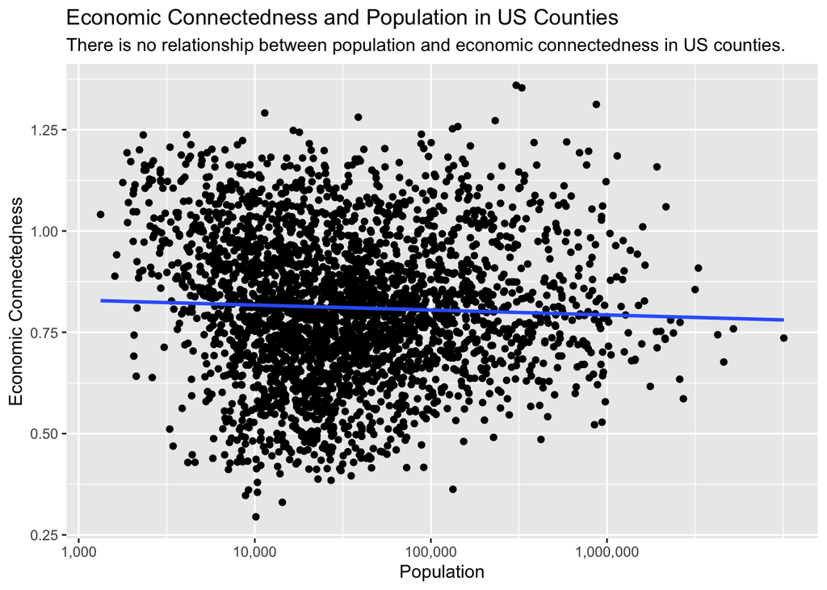

On Day 3, we open up the repo we were working on at the end of Day 2. Show how we can find that old project in the pull down menu, how we can either open it (and replace the current project) or open it as a new RStudio instance. Then, show how to find the .Rproj file and double-click on that.

Let’s now add a state variable. Tough to do! Getting the regular expression exactly correct is tricky! Note that we are just removing everything up to the first comma, and then the space which follows. I think that this gets everything correct but perhaps not.

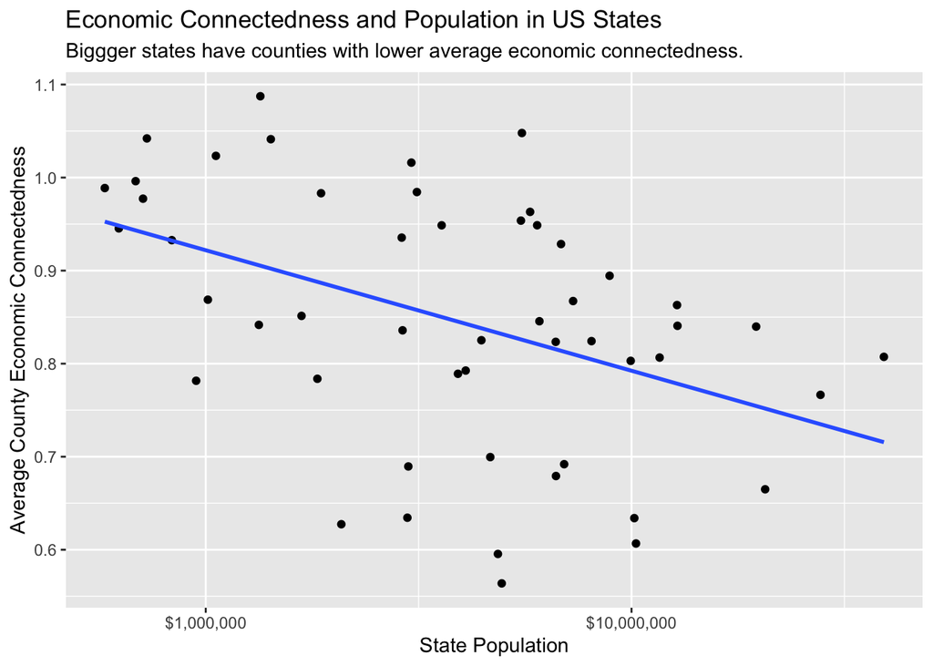

And that is enough for the week.